# Problem Set 08

Lauren Sullivan, BIO_SC 8002_01

Due April 22, 2022

## Rattlesnake morphometrics

### Background

We will be examining data from: Smith and Collyer 2008. In: [The Biology of Rattlesnakes](https://www.si.edu/object/siris_sil_946502). This is adapted from work by Dean Adams at Iowa State University.

The authors worked with 107 live prairie rattlesnakes to examine how different factors altered their head shape. Their independent variables included: region the snake was found in (Central, East, West), sex (male, female), and a measure of total body length - snout to vent length (SVL). Their dependent variables included a measurement of the outline distance of the head (head_shape), as well as a series of morphometric point measurements across the head at known regions (regions) that are a multivariate demonstration of head shape. The authors explored their snakes using both a univariate and a multivariate approach. In this homework, we will determine which approach is the most appropriate.

```r
###############
#
# 08 PROBLEM SET
#
# DUE:        April 22, 2022
#
# CREATED BY: Lauren Sullivan
# FILES:      "snakes.csv"
#
###############


########### setup
rm(list=ls())


library(tidyverse)


########### data
snakes <- read_csv("../data/snakes_data.csv")
```

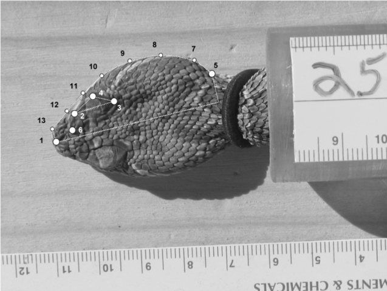

Where Smith and Collyer measured morphometric regions on the snake heads

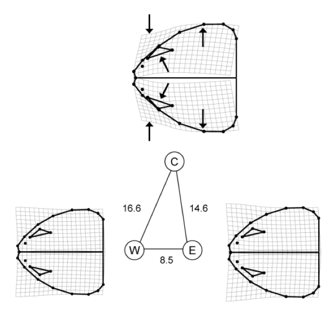

2D spline representation of the snake head location measurements from the central region (C) where snakes live in snady mammal burrows, and the east and west regions (E and W) where snakes live in rocky buttes.

## Univariate Model

**Q1** We will start with the univariate models, and will be examining if head shape is a function of the sex of a snake, and the region it is from. Let’s look at our data first. Create an appropriate plot to demonstrate the mean head shape (displayed as a point with error bars representing the standard error) of male and female snakes from different regions.

```r
#Here you have to group by Region and Sex because
# that's what the question is asking for a summary by.
# And you want to make sure you account for the fact that there
# are multiple rows per individuals in the standard
# error calculation - so use length(unique(Individual)) - which is
# the number of unique individuals within each Region and Sex (so
# the total n).

snake_summary <- snakes %>%
                  group_by(Region, Sex) %>%
                  dplyr::summarize(mean_hs = mean(head_shape),
                            se_hs = sd(head_shape)/
                              sqrt(length(unique(Individual))))
snake_summary
```

```
## # A tibble: 6 × 4
## # Groups:   Region [3]
##   Region  Sex   mean_hs se_hs
##   <chr>   <chr>   <dbl> <dbl>
## 1 Central F        768.  44.5
## 2 Central M        696.  33.8
## 3 East    F        640.  30.5
## 4 East    M        632.  29.1
## 5 West    F        610.  47.4
## 6 West    M        644.  39.7
```

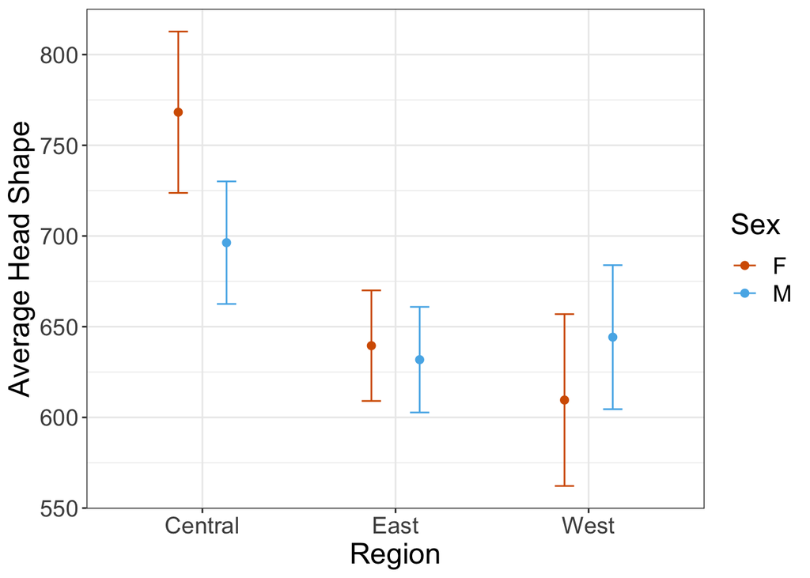

```r
colors <- c("#d55e00", "#56b4e9")

ggplot(snake_summary,aes(x = Region, y = mean_hs, color = Sex))+
  geom_point(position = position_dodge(width = .5),  size = 2)+
  geom_errorbar(aes(x = Region, ymin = mean_hs - se_hs, ymax = mean_hs +
                      se_hs, color = Sex), position = position_dodge(width = .5),
                width = .2)+
  theme_bw()+
  theme(text = element_text(size=18))+
  scale_color_manual(values=colors)+
  labs(x = "Region", y = "Average Head Shape")
```

**Q2** Run the correct univariate model to examine $headshape \sim Region * Sex$. What is this model called? What are the results of the model?

```r
model_2 <- lm(head_shape ~ Region * Sex, data = snakes)
anova(model_2)
```

```
## Analysis of Variance Table
##
## Response: head_shape
##              Df   Sum Sq Mean Sq F value    Pr(>F)
## Region        2  3213226 1606613 51.3150 < 2.2e-16 ***
## Sex           1    11247   11247  0.3592     0.549
## Region:Sex    2   780252  390126 12.4606 4.268e-06 ***
## Residuals  1599 50062837   31309
## ---
## Signif. codes:  0 '***' 0.001 '**' 0.01 '*' 0.05 '.' 0.1 ' ' 1
```

```r
# This model is called a factorial ANOVA.
# There is a significant interaction between Region and Sex.
#   In the Central region, snakes have overall bigger heads,
#   and the female snakes have larger heads than male snakes
#   in the East region the snakes have smaller heads overall but
#   the male and female snakes have the same size heads. And in
#   the West region, male snakes have slightly larger heads than
#   females (but the size overlaps quite a bit), but overall
#   their head seizes are about the same as in the east region.
```

**Q3** It might also be important to take into account the overall size of each snake. Run the correct univariate model to examine how Region, Sex and SVL affect head shape. What does your model look like and why did you choose that formulation? What is this model called? What are the results of the model? Create a figure that demonstrates this result.

```r
model_3 <- lm(head_shape ~ Region * Sex * SVL, data = snakes)
anova(model_3)
```

```
## Analysis of Variance Table
##
## Response: head_shape
##                  Df   Sum Sq Mean Sq  F value    Pr(>F)
## Region            2  3213226 1606613  57.6198 < 2.2e-16 ***
## Sex               1    11247   11247   0.4034 0.5254502
## SVL               1  4387986 4387986 157.3712 < 2.2e-16 ***
## Region:Sex        2   795701  397851  14.2686 7.213e-07 ***
## Region:SVL        2   738513  369257  13.2431 1.977e-06 ***
## Sex:SVL           1     6348    6348   0.2277 0.6333242
## Region:Sex:SVL    2   496887  248444   8.9102 0.0001418 ***
## Residuals      1593 44417653   27883
## ---
## Signif. codes:  0 '***' 0.001 '**' 0.01 '*' 0.05 '.' 0.1 ' ' 1
```

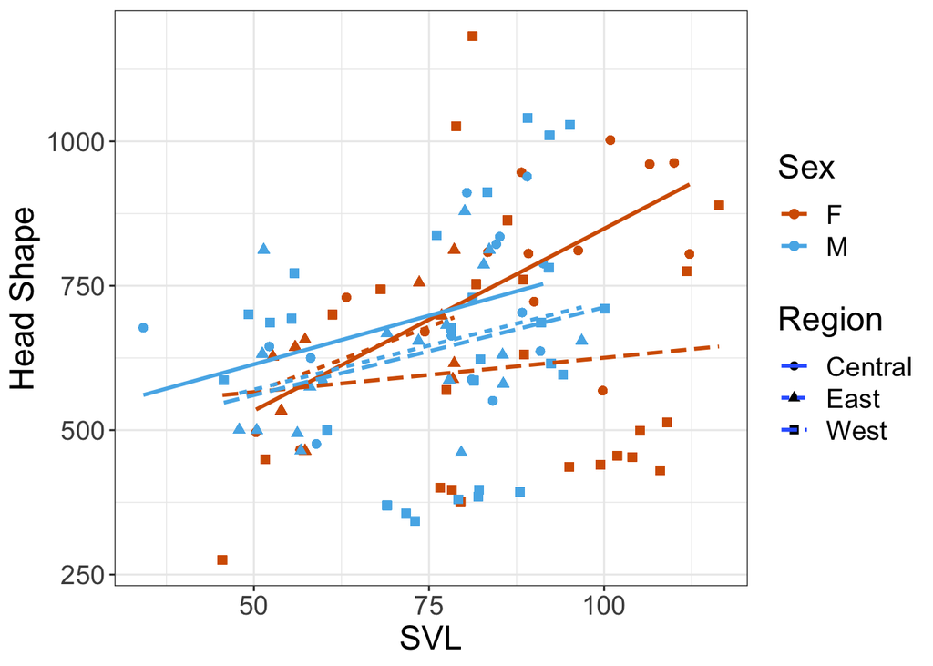

```r
# This model is an ANCOVA

# I chose an interactive model between Region * Sex *
#   SVL because this model turned out to be significant.

# There is a three way interaction between Region, Sex and
#   SVL. The relationship between SVL and headshape is different
#   for male and female snakes in different Regions (aka the
#   slopes are different.)

ggplot(snakes, aes(x = SVL, y = head_shape, color = Sex,
                   shape = Region, linetype = Region))+
  geom_point(size = 2)+
  geom_smooth(method = "lm", se=FALSE)+
  theme_bw()+
  theme(text = element_text(size=18))+
  scale_color_manual(values=colors)+
  labs(x = "SVL", y = "Head Shape")
```

## Multivariate Models

**Q4** Ok, so there appears to be an interesting univariate pattern, but what about with the multivariate head shape data? Do we see different patterns when we look at more than one measurement of head shape? Let’s start by cleaning our data. You can see in our dataset snakes we have one column called “region” and there are 15 places where measurements were taken (RW1 - RW15), and their associated measurement value is in the “location” column. Tidy this data so you have one column for each of the 15 regions measured.

```r
snakes_wide <- snakes %>%
                pivot_wider(names_from = "region", values_from = "location")
snakes_wide
```

```
## # A tibble: 107 × 20
##    Individual Region  Sex     SVL head_shape      RW1      RW2      RW3      RW4
##         <dbl> <chr>   <chr> <dbl>      <dbl>    <dbl>    <dbl>    <dbl>    <dbl>
##  1          1 Central F     112.        805.  1.86e-2 -0.00943  0.00358 -0.0239
##  2          2 Central F      90         722.  7.94e-4 -0.0187  -0.0460  -0.00330
##  3          3 Central F      63.2       730. -3.17e-2 -0.00459 -0.0272   0.00489
##  4          4 Central F      56.6       466. -7.31e-2 -0.0445  -0.0254  -0.0104
##  5          5 Central F      96.3       811.  6.70e-3  0.0530  -0.0484   0.00581
##  6          6 Central F      88.2       946.  4.25e-3  0.00276  0.0120   0.0132
##  7          7 Central F     110         963.  1.81e-2 -0.0148   0.0128   0.00523
##  8          8 Central F      89.2       806. -2.98e-2 -0.0283   0.0633   0.00674
##  9          9 Central F     106.        961.  7.96e-4  0.00522  0.0500   0.0149
## 10         10 Central F      74.4       670.  2.61e-2  0.0150  -0.0440   0.0181
## # … with 97 more rows, and 11 more variables: RW5 <dbl>, RW6 <dbl>, RW7 <dbl>,
## #   RW8 <dbl>, RW9 <dbl>, RW10 <dbl>, RW11 <dbl>, RW12 <dbl>, RW13 <dbl>,
## #   RW14 <dbl>, RW15 <dbl>
```

**Q5** You can now ignore the column for headshape, and consider our new set of Y variables to be RW1 - RW15. Run the MANCOVA that explores the relationship between **Y** and Region, Sex and SVL. Did you find a support for interactions or for an additive model? Why?

```r
Y <- as.matrix(snakes_wide[,6:15])
model_5 <- manova(Y ~ Region + Sex + SVL,
               data = snakes_wide)
summary(model_5)
```

```
##            Df  Pillai approx F num Df den Df    Pr(>F)
## Region      2 0.37837   2.1933     20    188 0.0034452 **
## Sex         1 0.12205   1.2928     10     93 0.2460230
## SVL         1 0.30197   4.0231     10     93 0.0001344 ***
## Residuals 102
## ---
## Signif. codes:  0 '***' 0.001 '**' 0.01 '*' 0.05 '.' 0.1 ' ' 1
```

```r
# Here I like the additive model of Region, Sex and SVL to
#   explain the multivariate set of head measurements. There
#   is a significant effect of Region (snakes have different head
#   shapes in different regions), but there is no effect of sex
#   when you consider the multivariate data. Also, there is a
#   significant effect of SVL on head shape.  As SVL gets larger,
#   head shapes change as well (need to plot the data to figure
#   out the direction of this relationship.)
```

**Q6** Create a figure that visualizes your model. Extract the PC1 axis as a representation of your **Y** for your y axis, and have your x axis be SVL, with different colors/shapes for Region and Sex as before. How do you interpret this figure?

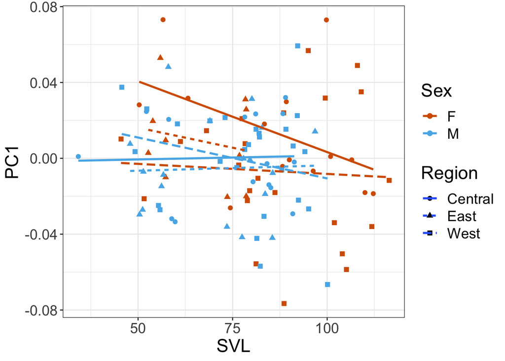

```r
PC1<-prcomp(Y)$x[,1]

dat <- data.frame(cbind(PC1, snakes_wide[,2:4]))

ggplot(dat, aes(x = SVL, y = PC1, color = Sex,
                   shape = Region, linetype = Region))+
  geom_point(size = 2)+
  geom_smooth(method = "lm", se=FALSE)+
  theme_bw()+
  theme(text = element_text(size=18))+
  scale_color_manual(values=colors)+
  labs(x = "SVL", y = "PC1")
```

```r
# Based on this figure, it looks that regions are definitely different for
#   head shape, and there is a slight negative relationship between
#   SVL and the headshape.  This is opposite to what we concluded with
#   our univariate analysis.
```

**Q7** Based on your results from your univariate and multivariate models, what analysis would you report on? You get different results depending on which model you choose, so why would you choose this one?